# PSYC2020L Assignment 13

[name]

2025-11-14

## Goals for Review:

- Correlation and Regression

## Setting Up

### 1) Rename this assignment as “Lab 13 Assignment [Last, First].Rmd”

### 2) Check and set (if needed) your working directory. If you’d like to load packages with `library()`, please do so in this block.

```r
here::here()
```

```
## [1] "C:/Users/jessi/OneDrive - Georgia Institute of Technology/Courses/GTA/PSYC2020L"
```

```r
library(tidyverse)
```

### 3) Download the `students_data.csv` dataset from Canvas. Relocate it to your folder for this class and import it into R. Please display the first few rows. Additionally, please use two other functions to get a sense of the data.

```r
students <- rio::import("student_data.csv")
head(students)
```

```
##   math_score reading_score writing_score gender        lunch
## 1         72            72            74 female     standard
## 2         69            90            88 female     standard
## 3         90            95            93 female     standard
## 4         47            57            44   male free/reduced
## 5         76            78            75   male     standard
## 6         71            83            78 female     standard
##   test_preparation_course
## 1                    none
## 2               completed
## 3                    none
## 4                    none
## 5                    none
## 6                    none
```

```r
str(students)
```

```
## 'data.frame':    1000 obs. of  6 variables:
##  $ math_score             : int  72 69 90 47 76 71 88 40 64 38 ...
##  $ reading_score          : int  72 90 95 57 78 83 95 43 64 60 ...
##  $ writing_score          : int  74 88 93 44 75 78 92 39 67 50 ...
##  $ gender                 : chr  "female" "female" "female" "male" ...
##  $ lunch                  : chr  "standard" "standard" "standard" "free/reduced" ...
##  $ test_preparation_course: chr  "none" "completed" "none" "none" ...
```

```r
summary(students)
```

```
##    math_score     reading_score    writing_score       gender
##  Min.   :  0.00   Min.   : 17.00   Min.   : 10.00   Length:1000
##  1st Qu.: 57.00   1st Qu.: 59.00   1st Qu.: 57.75   Class :character
##  Median : 66.00   Median : 70.00   Median : 69.00   Mode  :character
##  Mean   : 66.09   Mean   : 69.17   Mean   : 68.05
##  3rd Qu.: 77.00   3rd Qu.: 79.00   3rd Qu.: 79.00
##  Max.   :100.00   Max.   :100.00   Max.   :100.00
##     lunch           test_preparation_course
##  Length:1000        Length:1000
##  Class :character   Class :character
##  Mode  :character   Mode  :character
##
##
##
```

## Correlation

### 4) What is the correlation between `reading_score` and `writing_score`?

```r
cor(students$reading_score, students$writing_score)
```

```
## [1] 0.9545981
```

### 5) Please provide a brief interpretation of the correlation between `reading_score` and `writing_score` (1–2 sentences).

The strength of the linear relationship between reading score and writing score is .95.

## Regression

### 6) What is the mean of `math_score`?

```r
mean(students$math_score)
```

```
## [1] 66.089
```

### 7) Estimate an intercept-only model with `math_score` as the outcome variable. Display the output with `summary()`.

```r
m0 <- lm(math_score ~ 1, data = students)
summary(m0)
```

```
##
## Call:
## lm(formula = math_score ~ 1, data = students)
##
## Residuals:
##     Min      1Q  Median      3Q     Max
## -66.089  -9.089  -0.089  10.911  33.911
##
## Coefficients:
##             Estimate Std. Error t value Pr(>|t|)
## (Intercept)  66.0890     0.4795   137.8   <2e-16 ***
## ---
## Signif. codes:  0 '***' 0.001 '**' 0.01 '*' 0.05 '.' 0.1 ' ' 1
##
## Residual standard error: 15.16 on 999 degrees of freedom
```

### 8) Compare the results of (6) and (7). Are there similarities? If so, why?

The mean of `math_score` minimizes the squared errors between the observed values and the predicted value (the mean). This same property makes it the best estimate for a line of best fit, which is why the intercept estimate in (7) is the same as the mean.

### 9) Now, use `lm()` to estimate a model with `reading_score` as a predictor and `math score` as the outcome. Display the output with `summary()`.

```r
m1 <- lm(math_score ~ reading_score, data = students)
summary(m1)
```

```
##
## Call:
## lm(formula = math_score ~ reading_score, data = students)
##
## Residuals:
##      Min       1Q   Median       3Q      Max
## -24.3419  -6.3419  -0.0221   6.2713  24.6581
##
## Coefficients:
##               Estimate Std. Error t value Pr(>|t|)
## (Intercept)    7.35759    1.33818   5.498 4.87e-08 ***
## reading_score  0.84910    0.01893  44.855  < 2e-16 ***
## ---
## Signif. codes:  0 '***' 0.001 '**' 0.01 '*' 0.05 '.' 0.1 ' ' 1
##
## Residual standard error: 8.736 on 998 degrees of freedom
## Multiple R-squared:  0.6684, Adjusted R-squared:  0.6681
## F-statistic:  2012 on 1 and 998 DF,  p-value: < 2.2e-16
```

### 10) Use the model from (9) and the `predict()` functions to generate predicted values for `math_score` across values of `reading_score`. Choose the sequenced values of `reading_score` by first looking at the `range()` of `reading_score` values in the data.

```r
students |> select(reading_score) |> range()
```

```
## [1]  17 100
```

```r
predict(m1, data.frame(reading_score = 17:100)) # other values (like maybe 10--100) are okay, as long as they are not crazy unrealistic given the actual range of 17--100.
```

```
##        1        2        3        4        5        6        7        8
## 21.79229 22.64139 23.49049 24.33959 25.18869 26.03779 26.88689 27.73599
##        9       10       11       12       13       14       15       16
## 28.58509 29.43419 30.28329 31.13239 31.98149 32.83059 33.67969 34.52879
##       17       18       19       20       21       22       23       24
## 35.37789 36.22699 37.07610 37.92520 38.77430 39.62340 40.47250 41.32160
##       25       26       27       28       29       30       31       32
## 42.17070 43.01980 43.86890 44.71800 45.56710 46.41620 47.26530 48.11440
##       33       34       35       36       37       38       39       40
## 48.96350 49.81260 50.66170 51.51080 52.35990 53.20900 54.05810 54.90720
##       41       42       43       44       45       46       47       48
## 55.75630 56.60540 57.45450 58.30360 59.15270 60.00180 60.85090 61.70000
##       49       50       51       52       53       54       55       56
## 62.54910 63.39820 64.24730 65.09640 65.94550 66.79460 67.64370 68.49280
##       57       58       59       60       61       62       63       64
## 69.34190 70.19100 71.04010 71.88920 72.73830 73.58740 74.43650 75.28560
##       65       66       67       68       69       70       71       72
## 76.13470 76.98380 77.83290 78.68201 79.53111 80.38021 81.22931 82.07841
##       73       74       75       76       77       78       79       80
## 82.92751 83.77661 84.62571 85.47481 86.32391 87.17301 88.02211 88.87121
##       81       82       83       84
## 89.72031 90.56941 91.41851 92.26761
```

### 11) Create a scatterplot with `reading_score` on the x-axis and `math_score` on the y-axis. Overlay a `geom_line()` of the prediction line (line of best fit) as per the results of `predict()`.

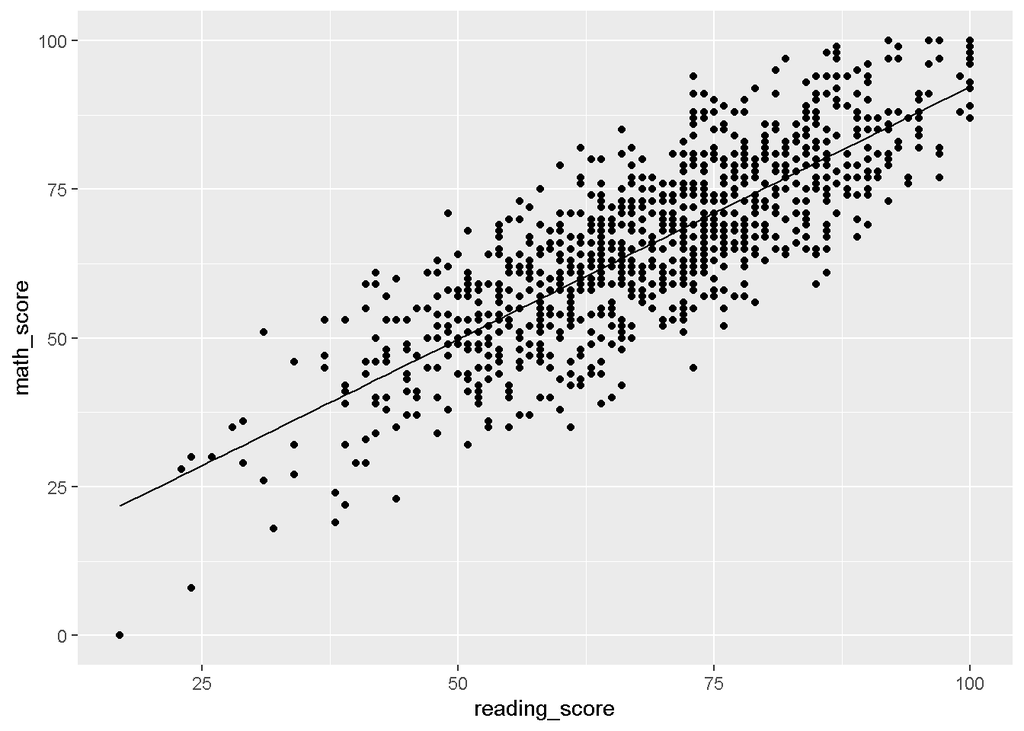

```r
predicted_data <- data.frame(reading_score = 17:100) |>
  mutate(predicted_math_score = predict(m1, data.frame(reading_score)))

students |>
  ggplot(aes(x = reading_score, y = math_score)) +
  geom_point() +
  geom_line(data = predicted_data, aes(y = predicted_math_score))
```

### 12) Provide a brief writeup of these results. Make sure to discuss both the intercept and slope estimates.

With every unit increase in reading score, the expected math score increases by 0.85 points. This is a significant increase (*p* < .001). When reading score is zero, the expected math_score is 7.36.

It’s OK to me if they don’t mention the *p*-values.

### 13) Now, use `lm()` to estimate a model with `reading_score` and `writing_score` as predictors and `math score` as the outcome. Display the output with `summary()`.

```r
m2 <- lm(math_score ~ reading_score + writing_score, data = students)
summary(m2)
```

```
##
## Call:
## lm(formula = math_score ~ reading_score + writing_score, data = students)
##
## Residuals:
##      Min       1Q   Median       3Q      Max
## -23.8779  -6.1750   0.2693   6.0184  24.8727
##
## Coefficients:
##               Estimate Std. Error t value Pr(>|t|)
## (Intercept)    7.52409    1.32823   5.665 1.93e-08 ***
## reading_score  0.60129    0.06304   9.538  < 2e-16 ***
## writing_score  0.24942    0.06057   4.118 4.14e-05 ***
## ---
## Signif. codes:  0 '***' 0.001 '**' 0.01 '*' 0.05 '.' 0.1 ' ' 1
##
## Residual standard error: 8.667 on 997 degrees of freedom
## Multiple R-squared:  0.674,  Adjusted R-squared:  0.6733
## F-statistic:  1031 on 2 and 997 DF,  p-value: < 2.2e-16
```

### 14) Provide a brief writeup of these results. Make sure to discuss both the intercept and slope estimates. How do these results compare to the results from (9)?

The effects of both reading score and writing score were significant. With every unit increase in reading score, the expected increase in math score is 0.6 points, and with every unit increase in writing score, the expected increase in math score is 0.25 points. When reading score and writing score are zero, the expected math score is 7.52 points. The intercept is slightly higher than before, and the effect of reading score is less than before.